# Nanofish

# References

- Yang, Y., Macleod, M., Pan, J., Lagisz, M., Nakagawa, S. (2023). Advanced methods and implementations for the meta-analyses of animal models: current practices and future recommendations. Neurosci. Biobehav. Rev., 146 https://doi.org/10.1016/j.neubiorev.2022.105016
- https://www.metafor-project.org/doku.php/analyses:konstantopoulos2011
- Viechtbauer, W., & Cheung, M. W.-L. (2010). *Outlier and influence diagnostics for meta-analysis. Research Synthesis Methods, 1(2), 112–125.* doi:10.1002/jrsm.11
- Viechtbauer, W. (2010). Conducting meta-analyses in R with the metafor package. *Journal of Statistical Software, 36*(3), 1–48. https://doi.org/10.18637/jss.v036.i03
- Nakagawa, S., Lagisz, M., Jennions, M. D., Koricheva, J., Noble, D. W. A., Parker, T. H., Sánchez-Tójar, A., Yang, Y., & O’Dea, R. E. (2022). Methods for testing publication bias in ecological and evolutionary meta-analyses. *Methods in Ecology and Evolution*, 13, 4–21. https://doi.org/10.1111/2041-210X.13724
- Stanley, T. D. (2017). Limitations of PET-PEESE and Other Meta-Analysis Methods. *Social Psychological and Personality Science*, *8*(5), 581-591. https://doi.org/10.1177/1948550617693062
- Nakagawa, S., Lagisz, M., O’Dea, R. E., Rutkowska, J., Yang, Y., Noble, D. W., & Senior, A. M. (2021). The Orchard Plot: Cultivating Forest Plots for Use in Ecology, Evolution and Beyond. **Research Synthesis Methods**, 12: 4-12, https://doi.org/10.1002/jrsm.1424 (preprint = *EcoEvoRxiv* https://doi.org/10.32942/osf.io/epqa7)
- Harrer, M., Cuijpers, P., Furukawa, T.A., & Ebert, D.D. (2021). *Doing Meta-Analysis with R: A Hands-On Guide*. Boca Raton, FL and London: Chapman & Hall/CRC Press. ISBN 978-0-367-61007-4

# Load data

## Adjust classes and transformations

```
'data.frame':   467 obs. of  30 variables:
 $ StudyID             : Factor w/ 59 levels "2","3","4","5",..: 40 40 50 50 50 50 16 16 16 7 ...
 $ StudyCluster        : Factor w/ 34 levels "1","2","3","5",..: 4 4 5 5 5 5 4 4 4 18 ...
 $ Study               : Factor w/ 59 levels "Ašmonaitė et al., 2020",..: 1 1 2 2 2 2 3 3 3 4 ...
 $ Year                : int  2020 2020 2018 2018 2018 2018 2020 2020 2020 2019 ...
 $ EScluster           : Factor w/ 101 levels "1","2","3","4",..: 1 1 2 2 2 2 3 3 3 4 ...
 $ AdministrationRoute : Factor w/ 6 levels "Food","Injection",..: 1 1 4 4 4 4 1 1 1 4 ...
 $ Concentration_mg_L  : num  NA NA 0.26 0.69 0.26 0.69 NA NA NA 20 ...
 $ ParticleMaterial    : Factor w/ 7 levels "Aminoplast","LDPE",..: 6 3 1 1 1 1 3 3 3 6 ...
 $ Species             : Factor w/ 20 levels "Argyrosomus regius",..: 9 9 8 8 8 8 9 9 9 7 ...
 $ ParticleShape       : Factor w/ 4 levels "Irregular","Sphere",..: 2 2 2 2 2 2 2 2 2 2 ...
 $ Sex                 : Factor w/ 5 levels "F","F:M","FM",..: 5 5 5 5 5 5 5 5 5 NA ...
 $ DevelopmentalStage  : Factor w/ 5 levels "Embrio","Larva",..: 4 4 4 4 4 4 4 4 4 2 ...
 $ ExposureDurationCat : Factor w/ 3 levels "15 days +","5-15 days",..: 2 2 3 3 3 3 1 1 1 3 ...
 $ ExposureDurationDays: int  14 14 4 4 4 4 28 28 28 2 ...
```

[output cut: 16 more lines]

# Create variables

```r
RE_formula <- setNames(vector("list", length(outcomeslist)), outcomeslist)
mRF <- list()  # random effects formula investigation models
mRE <- list()  # random effects multilevel models
mMR <- list()  # multilevel metaregression models

colormap <- c(Embrio = "khaki", Larva = "lightgreen", Juvenile = "lightskyblue",
    Adult = "salmon", Unclear = "plum", ExposureDurationDays = "cornflowerblue",
    ParticleSizeMean = "chartreuse4", Concentration_mg_L = "chocolate4", `Publication year` = "black",
    Variance = "navyblue")
```

# Calculate Effect Size

```r
df_original <- metafor::escalc(measure = "SMD", n1i = n_treat, n2i = n_ctrl, m1i = mean_treat,
    m2i = mean_ctrl, sd1i = STD_treat, sd2i = STD_ctrl, data = df_original, vtype = "UB")
# write.csv(df_original,file = 'mvMetaAnalysis_SMDs.csv')
```

# Select outcome

```
[1] "AChE activity"
```

# Exploratory data analysis

## Funnel plot

> Before running any meta-analytic model, it is important to explore the meta-analytic dataset to search for potential outliers that could represent data extraction errors. (Nakagawa et al. 2022)

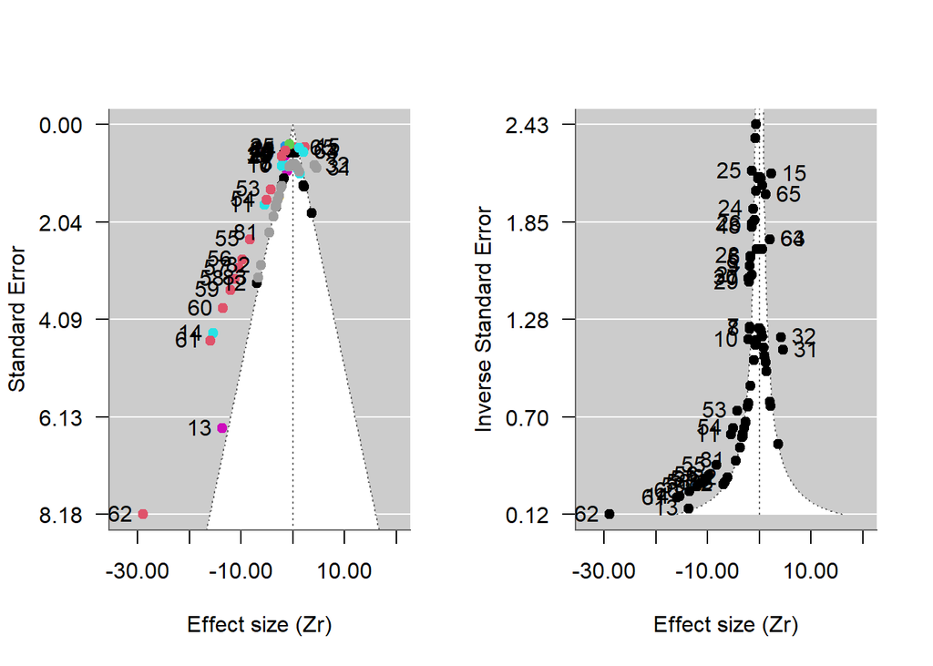

## Alluvial plot

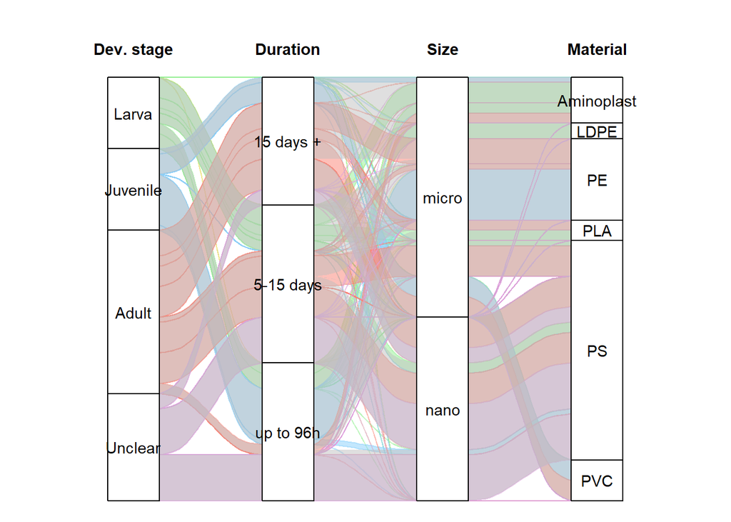

# Multilevel meta-analytic model

## Random effects formula desing

```
[1] "Considering number of studies: 25, number of ES clusters: 50 and number of independent observations of ES: 83, the random effects formula for AChE activity is: ~1 | Study/EScluster/ESid"
```

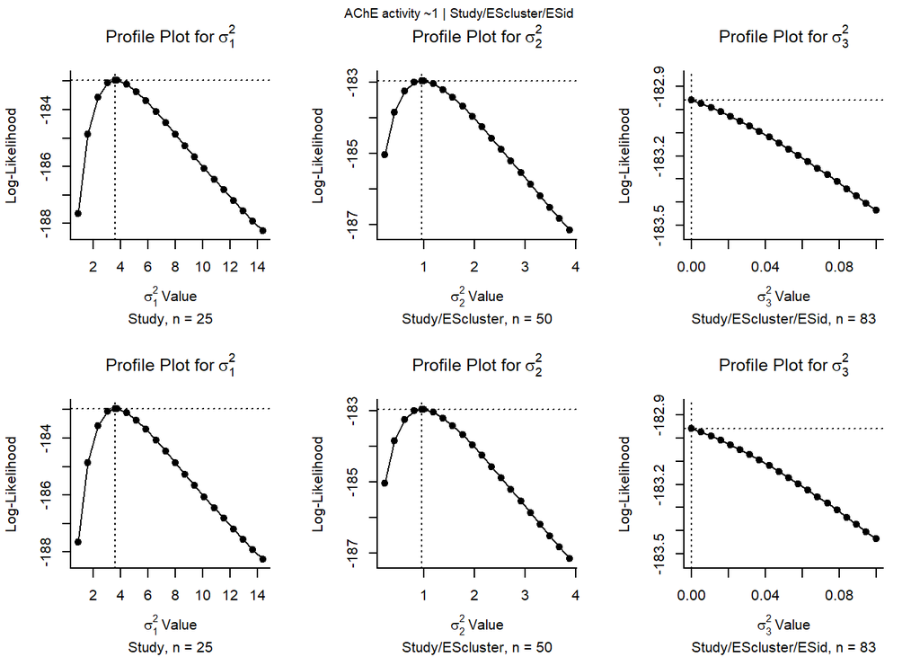

## Additional random effects factors

Study cluster, particle material and species as random effects term can further improve results?

|  | Nested | +StudyCluster | +Particle Material | +Species |
| --- | --- | --- | --- | --- |
| logLik: | -182.9595241115275 | -181.7204655159421 | -182.9595241133847 | -182.9595241118229 |
| deviance: | 202.893336714611 | 200.41521952344 | 202.8933367183253 | 202.8933367152018 |
| AIC: | 373.9190482230551 | 373.4409310318841 | 375.9190482267693 | 375.9190482236459 |
| BIC: | 383.5944106542415 | 385.5351340708671 | 388.0132512657523 | 388.0132512626288 |
| AICc: | 374.4318687358756 | 374.2201518111049 | 376.6982690059901 | 376.6982690028667 |

|  | Comparison | LRT | p_value |
| --- | --- | --- | --- |
| 1 | +Study Cluster | 2.48 | 0.115 |
| 2 | +Particle Material | 0 | 1 |
| 3 | +Species | 0 | 1 |

Additional term to insert: none

## Main result: Multilevel model with $\rho = 0.5$ and robust variance estimate

```r
# Assumed correlation of rho = 0.5, except if there is only one ES by Study (no
# correlation)
if (nES == nSt) {
    VCVrho <- 0
    VCV <- df$vi
} else {
    VCVrho <- 0.5
    VCV <- vcalc(vi, cluster = interaction(df$EScluster, df$Study), obs = ESid, data = df,
        rho = VCVrho)
}

mname1 <- "ML"
mname2 <- paste0(mname1, "_RobVar")

mRE[[mname1]] <- rma.mv(yi, VCV, random = RE_formula[[outcome]], data = df, slab = Study,
    method = "REML", test = "t", dfs = "contain", level = 95)
mRE[[mname1]] <- additional_results(mRE[[mname1]])

mRE[[mname2]] <- robust(mRE[[mname1]], cluster = df$Study, clubSandwich = TRUE)

mRE[[mname2]] <- additional_results(mRE[[mname2]])

I2_ML_RobVar <- i2_ml(mRE[[mname2]])
# I2_ML_RobVar <- i2_ml(mRE[[mname2]], boot = 1000)

extract_report(mRE[[mname2]], outcome, RE_formula)
```

#### Diagnostics plots and results

```
Multivariate Meta-Analysis Model (k = 83; method: REML)

   logLik   Deviance        AIC        BIC       AICc
-176.3571   352.7141   360.7141   370.3410   361.2336

Variance Components:

            estim    sqrt  nlvls  fixed                factor
sigma^2.1  2.9366  1.7136     25     no                 Study
sigma^2.2  0.0711  0.2666     50     no       Study/EScluster
sigma^2.3  0.1403  0.3746     83     no  Study/EScluster/ESid

Test for Heterogeneity:
Q(df = 82) = 310.2298, p-val < .0001

Number of estimates:   83
Number of clusters:    25
Estimates per cluster: 0-18 (mean: 1.41, median: 0)

Model Results:

estimate      se¹     tval¹     df¹    pval¹    ci.lb¹   ci.ub¹
 -0.6736  0.3771   -1.7861   23.03   0.0873   -1.4537   0.1065   .

---
Signif. codes:  0 '***' 0.001 '**' 0.01 '*' 0.05 '.' 0.1 ' ' 1

1) results based on cluster-robust inference (var-cov estimator: CR2,
   approx t-test and confidence interval, df: Satterthwaite approx)
```

```
               I2_Total                I2_Study      I2_Study/EScluster
              83.957985               78.320302                1.895987
I2_Study/EScluster/ESid
               3.741696
```

```
$results
        % of total variance    I2
Level 1           16.042015   ---
Level 2            3.741696  3.74
Level 3            1.895987   1.9
Level 4           78.320302 78.32

$totalI2
[1] 83.95798

$plot
```

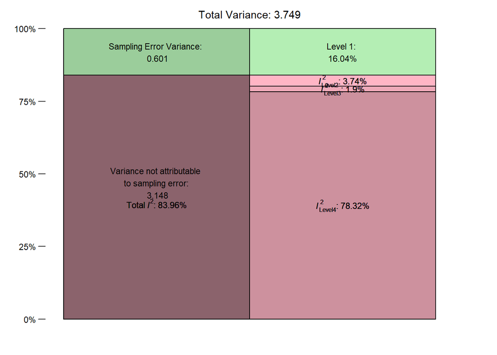

```
attr(,"class")
[1] "mlm.variance.distribution" "list"
```

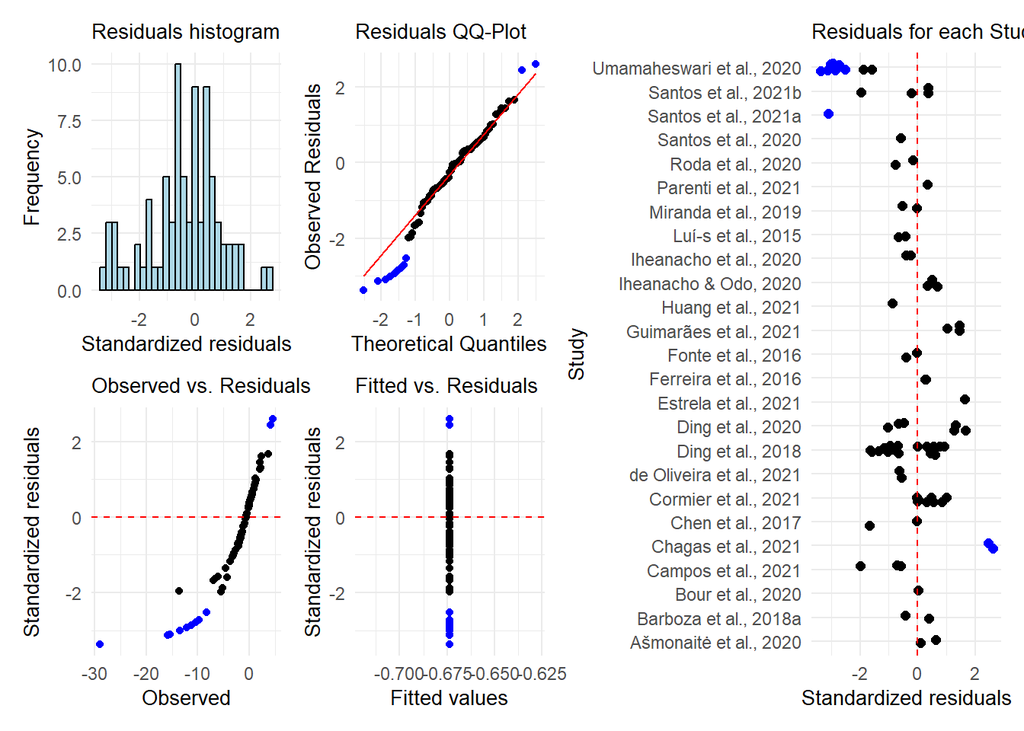

The meta-analysis comprised 83 comparisons from 50 control group clusters of 25 independent studies, so the random formula for AChE activity was ~1 | Study/EScluster/ESid.

No difference between treatment and control groups (ES = -0.673585 ± 0.3771363, CI95% = -1.453693 to 0.1065229, predicted interval -4.4256103 to 3.0784402), with high heterogeneity (i² = 83.96, Q = 310.2298484, p < 0.001 ) and variance explained by each component of $\sigma^2_{Study} = 2.94$, $\sigma^2_{EScluster} = 0.07$, $\sigma^2_{ESid} = 0.14$.

# Publication bias

> **Small-study effect:** when small studies (with small sample sizes) tend to report large effect sizes. (Yang et al. 2023)

> While the PET method works best when the true effect captured by β0β0 is **zero**, PEESE shows a better performance when the true effect is **not** zero. Stanley and Doucouliagos ([2014](https://bookdown.org/MathiasHarrer/Doing_Meta_Analysis_in_R/references.html#ref-stanley2014meta)) therefore proposed to combine both methods, in order to balance out their individual strengths. The resulting approach is the PET-PEESE method. PET-PEESE uses the intercept β0 of either PET or PEESE as the estimate of the corrected true effect.

> Whether PET or PEESE is used depends on the size of the intercept calculated by the PET method. When β0PET is significantly larger than zero in a one-sided test with α = 0.05, we use the intercept of PEESE as the true effect size estimate. If PET’s intercept is not significantly larger than zero, we remain with the PET estimate.

> In most implementations of regression models in *R*, it is conventional to test the significance of coefficients using a two-sided test (i.e. we test if a ββ weight significantly differs from zero, no matter the direction). To assume a one-sided test with α = 0.05, we already regard the intercept as significant when p < 0.1, and when the estimate of β0 is larger than zero<sup>38</sup>. (Harrer et al., n.d.)

> **Time-lag bias:** when statistically significant (“positive” results) tend to be published earlier than those with statistically non-significant findings (“negative” results), leading to a decline in reported effect sizes over time (i.e., a decline effect). (Yang et al. 2023)

> Given that high heterogeneity may invalidate publication bias test, it is best to account for the potential heterogeneity when testing publication bias. (Yang et al. 2023)

So, **better use meta-regression dataset**, but requires larger dataset to avoid possible convergence issues.

#### Plots

```
[1] "PEESE"
```

```
Multivariate Meta-Analysis Model (k = 83; method: REML)

   logLik   Deviance        AIC        BIC       AICc
-140.3309   280.6617   292.6617   306.9539   293.8124

Variance Components:

            estim    sqrt  nlvls  fixed                factor
sigma^2.1  1.9765  1.4059     25     no                 Study
sigma^2.2  0.0000  0.0001     50     no       Study/EScluster
sigma^2.3  0.0709  0.2663     83     no  Study/EScluster/ESid

Test for Residual Heterogeneity:
QE(df = 80) = 212.2688, p-val < .0001

Number of estimates:   83
Number of clusters:    25
Estimates per cluster: 0-18 (mean: 1.41, median: 0)

Test of Moderators (coefficients 2:3):¹
F(df1 = 2, df2 = 3.88) = 19.9294, p-val = 0.0091

Model Results:

          estimate      se¹     tval¹     df¹    pval¹    ci.lb¹    ci.ub¹
intrcpt    -0.2861  0.2912   -0.9823   15.69   0.3409   -0.9045    0.3323
vi         -0.5705  0.0817   -6.9803    2.28   0.0138   -0.8834   -0.2576   *
pub_year    0.2160  0.1314    1.6431    6.21   0.1498   -0.1031    0.5350

---
Signif. codes:  0 '***' 0.001 '**' 0.01 '*' 0.05 '.' 0.1 ' ' 1

1) results based on cluster-robust inference (var-cov estimator: CR2,
   approx t/F-tests and confidence intervals, df: Satterthwaite approx)
```

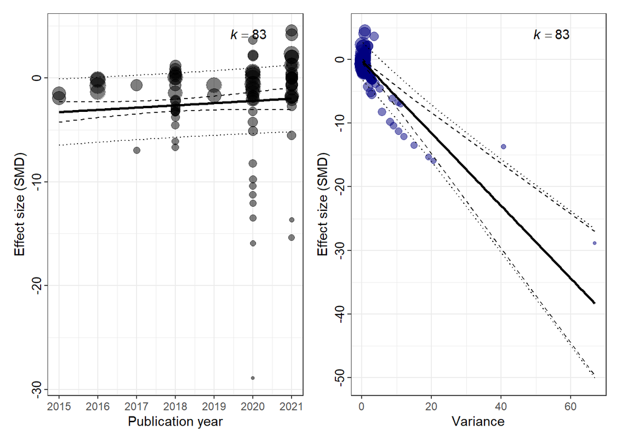

**Small-study effect** The regression slope of the extended Egger’s regression is $\sqrt{SMDSE} = -0.5704975$ is it statistically different from zero?`

If p<0.050: Smaller studies (with larger sampling error) have larger effect sizes –> small-study effect exists in this dataset. Data is assymmetrically distributed in the funnel plot.

If p>=0.050 no small-study effect exists in this dataset. Smaller studies (with larger sampling error) do not have larger effect sizes –> no small-study effect exists in this dataset. Data is symmetrically distributed in the funnel plot.

If p<0.050: studies with statistically significant findings tend to be published earlier than these with “negative” results, i.e. time-lag bias exists in this dataset

If p>=0.050: studies with statistically significant findings **do not** tend to be published earlier than these with “negative” results, i.e. no time-lag bias exists in this dataset

> Egger’s regression and its variants suffer from low power and poor performance when there are fewer than 20 effect sizes, or when the overall effect is large. (Nakagawa et al. 2022)

> Instead of the sample size (n1 + n2), however, for a meta-analysis of SMD or lnRR, we propose using the ‘effective sample size’ because it accounts for unbalanced sampling (cf. Stanley, 2005).(Nakagawa et al. 2022)

```r
if (mRE[[bias]]$pval[2] < 0.05) {

    # calculate modified SE based on effective sample size
    df$ess_vi <- with(df, sqrt((n_treat + n_ctrl)/(n_treat * n_ctrl)))
    df$ess_SE <- sqrt(df$ess_vi)  ## sampling error for ES

    # PET + year
    bias2 <- "PET sensitivity"
    mRE[[bias2]] <- rma.mv(yi, VCV, random = RE_formula[[outcome]], mods = ~ess_SE +
        pub_year, data = df, slab = Study, method = "REML", test = "t", dfs = "contain",
        level = 95)
    mRE[[bias2]] <- robust(mRE[[bias2]], cluster = df$Study, clubSandwich = TRUE)
    mRE[[bias2]] <- additional_results(mRE[[bias2]])

    # PEESE + year
    if (mRE[[bias2]]$pval[2] < 0.1) {
        mname <- "PEESE sensitivity"
        mRE[[mname]] <- rma.mv(yi, VCV, random = RE_formula[[outcome]], mods = ~ess_vi +
            pub_year, data = df, slab = Study, method = "REML", test = "t", dfs = "contain",
            level = 95)
        mRE[[mname]] <- robust(mRE[[mname]], cluster = df$Study, clubSandwich = TRUE)
        mRE[[mname]] <- additional_results(mRE[[mname]])
        bias2 <- mname
    }
    print(bias2)
    summary(mRE[[bias2]])
}
```

```
[1] "PET sensitivity"
```

```
Multivariate Meta-Analysis Model (k = 83; method: REML)

   logLik   Deviance        AIC        BIC       AICc
-171.0944   342.1888   354.1888   368.4810   355.3395

Variance Components:

            estim    sqrt  nlvls  fixed                factor
sigma^2.1  2.9463  1.7165     25     no                 Study
sigma^2.2  0.0531  0.2305     50     no       Study/EScluster
sigma^2.3  0.1458  0.3818     83     no  Study/EScluster/ESid

Test for Residual Heterogeneity:
QE(df = 80) = 289.5438, p-val < .0001

Number of estimates:   83
Number of clusters:    25
Estimates per cluster: 0-18 (mean: 1.41, median: 0)

Test of Moderators (coefficients 2:3):¹
F(df1 = 2, df2 = 8.49) = 1.1238, p-val = 0.3690

Model Results:

          estimate      se¹     tval¹     df¹    pval¹     ci.lb¹   ci.ub¹
intrcpt     3.0626  2.4730    1.2385   13.12   0.2372    -2.2748   8.4000
ess_SE     -5.0365  3.2288   -1.5599   12.07   0.1446   -12.0672   1.9941
pub_year    0.1688  0.1581    1.0676    6.44   0.3241    -0.2118   0.5495

---
Signif. codes:  0 '***' 0.001 '**' 0.01 '*' 0.05 '.' 0.1 ' ' 1

1) results based on cluster-robust inference (var-cov estimator: CR2,
   approx t/F-tests and confidence intervals, df: Satterthwaite approx)
```

If the results are the same, indicates the robustness of the small-study test.

#### Plots

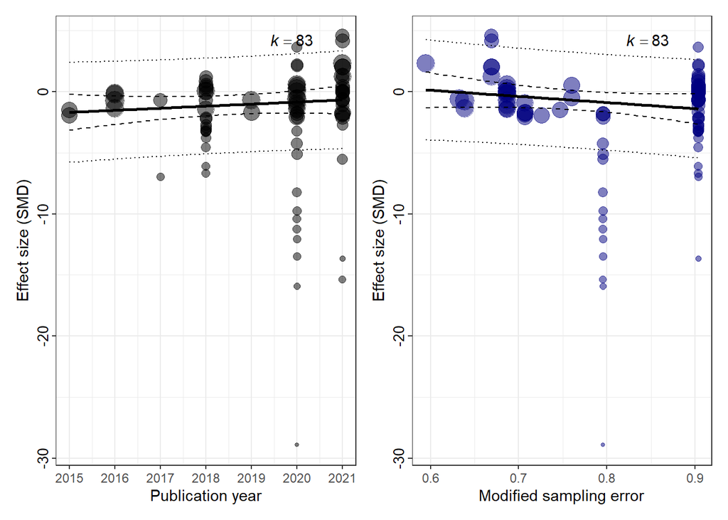

# Sensitivity

## Rho range

```r
if (VCVrho != 0) {

    rho_range <- c(0, 0.25, 0.75, 0.9)  # assume a range values of rho

    for (j in 1:length(rho_range)) {

        mname <- paste("rho", rho_range[j], sep = "_")

        VCV2 <- vcalc(vi, cluster = interaction(df$EScluster, df$Study), obs = ESid,
            data = df, rho = rho_range[j])

        mRE[[mname]] <- rma.mv(yi, VCV2, random = RE_formula[[outcome]], data = df,
            slab = Study, method = "REML", test = "t", dfs = "contain", level = 95)
        mRE[[mname]] <- robust(mRE[[mname]], cluster = df$Study, clubSandwich = TRUE)
        mRE[[mname]] <- additional_results(mRE[[mname]])
    }
}
```

## Leave one out + Rho range

```r
if (VCVrho != 0) {
    rho_range <- c(0.25, 0.5, 0.75, 0.9)
} else {
    rho_range <- 0
}

for (i in sort(unique(df$Study))) {

    df_temp <- df[df$Study != i, ]

    for (j in 1:length(rho_range)) {

        mname <- paste("rho", rho_range[j], "l1o", i, sep = "_")
        print(mname)
        VCV2 <- vcalc(vi, cluster = interaction(df_temp$EScluster, df_temp$Study),
            obs = ESid, data = df_temp, rho = rho_range[j])

        mRE[[mname]] <- rma.mv(yi, VCV2, random = RE_formula[[outcome]], data = df_temp,
            slab = Study, method = "REML", test = "t", dfs = "contain", level = 95)
        mRE[[mname]] <- robust(mRE[[mname]], cluster = df_temp$Study, clubSandwich = TRUE)
        mRE[[mname]] <- additional_results(mRE[[mname]])
    }
}
```

[output not shown]

[output cut: 85 more lines]

# Tables

|  | n.studies | n.ES.clusters | n.ES | overall.effect | standard.error | p.value | Lower.CI | Upper.CI | Lower.PI | Upper.PI | Q | Q.p.value | I.total | I.Study | I.EScluster | I.ES | σ.Study | σ.EScluster | σ.ES |
| --- | --- | --- | --- | --- | --- | --- | --- | --- | --- | --- | --- | --- | --- | --- | --- | --- | --- | --- | --- |
| ML | 25 | 50 | 83 | -0.67 | 0.4 | 0.0862 | -1.45 | 0.10 | -4.42 | 3.07 | 310.23 | 0 | 83.96 | 78.32 | 1.90 | 3.74 | 2.94 | 0.07 | 0.14 |
| ML_RobVar | 25 | 50 | 83 | -0.67 | 0.4 | 0.0873 | -1.45 | 0.11 | -4.43 | 3.08 | 310.23 | 0 | 83.96 | 78.32 | 1.90 | 3.74 | 2.94 | 0.07 | 0.14 |
| PET | 25 | 50 | 83 | 1.69 | 0.3 | 0.0001 | 1.00 | 2.39 | -1.42 | 4.81 | 207.51 | 0 | 77.15 | 75.39 | 0.00 | 1.76 | 1.98 | 0.00 | 0.05 |
| PEESE | 25 | 50 | 83 | -0.29 | 0.3 | 0.3409 | -0.90 | 0.33 | -3.39 | 2.81 | 212.27 | 0 | 77.29 | 74.61 | 0.00 | 2.68 | 1.98 | 0.00 | 0.07 |
| PET sensitivity | 25 | 50 | 83 | 3.06 | 2.5 | 0.2372 | -2.27 | 8.40 | -3.51 | 9.63 | 289.54 | 0 | 83.95 | 78.64 | 1.42 | 3.89 | 2.95 | 0.05 | 0.15 |
| rho_0 | 25 | 50 | 83 | -0.90 | 0.4 | 0.0554 | -1.83 | 0.02 | -5.53 | 3.72 | 408.59 | 0 | 88.86 | 70.70 | 18.16 | 0.00 | 3.82 | 0.98 | 0.00 |
| rho_0.25 | 25 | 50 | 83 | -0.79 | 0.4 | 0.0674 | -1.64 | 0.06 | -4.95 | 3.37 | 340.41 | 0 | 86.58 | 75.43 | 10.28 | 0.87 | 3.38 | 0.46 | 0.04 |
| rho_0.75 | 25 | 50 | 83 | -0.58 | 0.3 | 0.1053 | -1.29 | 0.13 | -4.01 | 2.85 | 321.27 | 0 | 81.37 | 70.73 | 0.00 | 10.64 | 2.28 | 0.00 | 0.34 |
| rho_0.9 | 25 | 50 | 83 | -0.52 | 0.3 | 0.1136 | -1.18 | 0.13 | -3.75 | 2.70 | 424.24 | 0 | 79.47 | 60.33 | 0.00 | 19.14 | 1.77 | 0.00 | 0.56 |
| rho_0.25_l1o_Ašmonaitė et al., 2020 | 24 | 49 | 81 | -0.83 | 0.4 | 0.0669 | -1.72 | 0.06 | -5.11 | 3.45 | 337.58 | 0 | 86.94 | 76.14 | 10.21 | 0.59 | 3.57 | 0.48 | 0.03 |
| rho_0.5_l1o_Ašmonaitė et al., 2020 | 24 | 49 | 81 | -0.71 | 0.4 | 0.0865 | -1.53 | 0.11 | -4.57 | 3.16 | 306.59 | 0 | 84.42 | 78.96 | 2.25 | 3.21 | 3.11 | 0.09 | 0.13 |
| rho_0.75_l1o_Ašmonaitė et al., 2020 | 24 | 49 | 81 | -0.61 | 0.4 | 0.1047 | -1.36 | 0.14 | -4.15 | 2.93 | 314.97 | 0 | 81.94 | 71.83 | 0.00 | 10.10 | 2.44 | 0.00 | 0.34 |
| rho_0.9_l1o_Ašmonaitė et al., 2020 | 24 | 49 | 81 | -0.55 | 0.3 | 0.1119 | -1.25 | 0.14 | -3.89 | 2.78 | 409.57 | 0 | 80.16 | 61.58 | 0.00 | 18.58 | 1.90 | 0.00 | 0.57 |
| rho_0.25_l1o_Barboza et al., 2018a | 24 | 49 | 81 | -0.80 | 0.4 | 0.0763 | -1.69 | 0.09 | -5.08 | 3.48 | 334.34 | 0 | 86.75 | 76.44 | 10.31 | 0.00 | 3.59 | 0.48 | 0.00 |
| rho_0.5_l1o_Barboza et al., 2018a | 24 | 49 | 81 | -0.67 | 0.4 | 0.1014 | -1.48 | 0.14 | -4.48 | 3.14 | 301.37 | 0 | 83.83 | 79.36 | 3.83 | 0.63 | 3.06 | 0.15 | 0.02 |
| rho_0.75_l1o_Barboza et al., 2018a | 24 | 49 | 81 | -0.56 | 0.4 | 0.1301 | -1.30 | 0.18 | -4.05 | 2.93 | 303.96 | 0 | 81.27 | 73.12 | 0.00 | 8.15 | 2.43 | 0.00 | 0.27 |
| rho_0.9_l1o_Barboza et al., 2018a | 24 | 49 | 81 | -0.51 | 0.3 | 0.1385 | -1.20 | 0.18 | -3.82 | 2.80 | 382.42 | 0 | 79.66 | 62.26 | 0.00 | 17.40 | 1.90 | 0.00 | 0.53 |
| rho_0.25_l1o_Bour et al., 2020 | 24 | 49 | 82 | -0.80 | 0.4 | 0.0760 | -1.70 | 0.09 | -5.11 | 3.50 | 340.19 | 0 | 86.92 | 76.02 | 10.04 | 0.85 | 3.61 | 0.48 | 0.04 |
| rho_0.5_l1o_Bour et al., 2020 | 24 | 49 | 82 | -0.68 | 0.4 | 0.0988 | -1.51 | 0.14 | -4.57 | 3.20 | 310.00 | 0 | 84.41 | 78.84 | 1.98 | 3.58 | 3.14 | 0.08 | 0.14 |
| rho_0.75_l1o_Bour et al., 2020 | 24 | 49 | 82 | -0.58 | 0.4 | 0.1201 | -1.33 | 0.17 | -4.14 | 2.97 | 320.90 | 0 | 81.86 | 71.64 | 0.00 | 10.22 | 2.45 | 0.00 | 0.35 |
| rho_0.9_l1o_Bour et al., 2020 | 24 | 49 | 82 | -0.53 | 0.3 | 0.1300 | -1.22 | 0.17 | -3.86 | 2.81 | 423.22 | 0 | 79.96 | 61.55 | 0.00 | 18.40 | 1.91 | 0.00 | 0.57 |
| rho_0.25_l1o_Campos et al., 2021 | 24 | 49 | 80 | -0.74 | 0.4 | 0.0962 | -1.62 | 0.14 | -4.97 | 3.50 | 329.08 | 0 | 87.06 | 76.12 | 10.11 | 0.83 | 3.49 | 0.46 | 0.04 |
| rho_0.5_l1o_Campos et al., 2021 | 24 | 49 | 80 | -0.63 | 0.4 | 0.1201 | -1.44 | 0.18 | -4.46 | 3.19 | 300.76 | 0 | 84.56 | 79.11 | 1.96 | 3.49 | 3.04 | 0.08 | 0.13 |
| rho_0.75_l1o_Campos et al., 2021 | 24 | 49 | 80 | -0.54 | 0.4 | 0.1410 | -1.28 | 0.19 | -4.03 | 2.94 | 311.28 | 0 | 81.98 | 72.38 | 0.00 | 9.60 | 2.38 | 0.00 | 0.32 |
| rho_0.9_l1o_Campos et al., 2021 | 24 | 49 | 80 | -0.48 | 0.3 | 0.1540 | -1.16 | 0.20 | -3.75 | 2.78 | 409.92 | 0 | 79.94 | 62.55 | 0.00 | 17.39 | 1.85 | 0.00 | 0.51 |
| rho_0.25_l1o_Chagas et al., 2021 | 24 | 49 | 81 | -0.95 | 0.4 | 0.0151 | -1.70 | -0.20 | -4.51 | 2.60 | 292.94 | 0 | 82.42 | 69.90 | 11.24 | 1.27 | 2.38 | 0.38 | 0.04 |
| rho_0.5_l1o_Chagas et al., 2021 | 24 | 49 | 81 | -0.82 | 0.3 | 0.0178 | -1.49 | -0.16 | -3.92 | 2.27 | 270.78 | 0 | 77.97 | 71.83 | 0.67 | 5.47 | 1.95 | 0.02 | 0.15 |
| rho_0.75_l1o_Chagas et al., 2021 | 24 | 49 | 81 | -0.73 | 0.3 | 0.0196 | -1.32 | -0.13 | -3.52 | 2.07 | 288.22 | 0 | 74.33 | 59.36 | 0.00 | 14.98 | 1.38 | 0.00 | 0.35 |
| rho_0.9_l1o_Chagas et al., 2021 | 24 | 49 | 81 | -0.66 | 0.3 | 0.0195 | -1.21 | -0.12 | -3.29 | 1.96 | 395.88 | 0 | 71.87 | 45.50 | 0.00 | 26.37 | 0.97 | 0.00 | 0.56 |
| rho_0.25_l1o_Chen et al., 2017 | 24 | 49 | 81 | -0.80 | 0.4 | 0.0769 | -1.69 | 0.09 | -5.08 | 3.49 | 336.53 | 0 | 87.33 | 76.40 | 10.13 | 0.80 | 3.58 | 0.47 | 0.04 |

[output cut: 79 more lines]

|  | ML | ML_RobVar | PET | PEESE | PET.sensitivity | rho_0 | rho_0.25 | rho_0.75 | rho_0.9 | rho_0.25_l1o_Ašmonaitė.et.al...2020 | rho_0.5_l1o_Ašmonaitė.et.al...2020 | rho_0.75_l1o_Ašmonaitė.et.al...2020 | rho_0.9_l1o_Ašmonaitė.et.al...2020 | rho_0.25_l1o_Barboza.et.al...2018a | rho_0.5_l1o_Barboza.et.al...2018a | rho_0.75_l1o_Barboza.et.al...2018a | rho_0.9_l1o_Barboza.et.al...2018a | rho_0.25_l1o_Bour.et.al...2020 | rho_0.5_l1o_Bour.et.al...2020 | rho_0.75_l1o_Bour.et.al...2020 | rho_0.9_l1o_Bour.et.al...2020 | rho_0.25_l1o_Campos.et.al...2021 | rho_0.5_l1o_Campos.et.al...2021 | rho_0.75_l1o_Campos.et.al...2021 | rho_0.9_l1o_Campos.et.al...2021 | rho_0.25_l1o_Chagas.et.al...2021 | rho_0.5_l1o_Chagas.et.al...2021 | rho_0.75_l1o_Chagas.et.al...2021 | rho_0.9_l1o_Chagas.et.al...2021 | … |
| --- | --- | --- | --- | --- | --- | --- | --- | --- | --- | --- | --- | --- | --- | --- | --- | --- | --- | --- | --- | --- | --- | --- | --- | --- | --- | --- | --- | --- | --- | --- |
| logLik: | -176.357059136584 | -176.357059136584 | -132.2871857235742 | -140.3308605032927 | -171.0944242301602 | -180.6496092780655 | -178.0436847023808 | -176.492319573645 | -177.4567589823594 | -174.8079190132937 | -173.2430586766004 | -173.5473057489114 | -174.5882387540683 | -173.0768349062404 | -171.6082154016253 | -172.7320348480789 | -174.0920795452531 | -176.3920372721179 | -174.8069357593744 | -175.0287546019303 | -176.049843059403 | -171.3448670108726 | -169.4227155248407 | -169.2397122936524 | -170.0902763952687 | -171.8019066091363 | -169.7193175124114 | -169.3925299448901 | -169.8619861704887 | … |
| deviance: | 352.7141182731681 | 352.7141182731681 | 264.5743714471484 | 280.6617210065854 | 342.1888484603204 | 361.299218556131 | 356.0873694047615 | 352.98463914729 | 354.9135179647188 | 349.6158380265873 | 346.4861173532008 | 347.0946114978228 | 349.1764775081365 | 346.1536698124808 | 343.2164308032507 | 345.4640696961577 | 348.1841590905062 | 352.7840745442358 | 349.6138715187488 | 350.0575092038606 | 352.0996861188061 | 342.6897340217453 | 338.8454310496815 | 338.4794245873047 | 340.1805527905374 | 343.6038132182726 | 339.4386350248229 | 338.7850598897802 | 339.7239723409774 | … |
| AIC: | 360.7141182731681 | 360.7141182731681 | 276.5743714471484 | 292.6617210065854 | 354.1888484603204 | 369.299218556131 | 364.0873694047615 | 360.98463914729 | 362.9135179647188 | 357.6158380265873 | 354.4861173532008 | 355.0946114978228 | 357.1764775081365 | 354.1536698124808 | 351.2164308032507 | 353.4640696961577 | 356.1841590905062 | 360.7840745442358 | 357.6138715187488 | 358.0575092038606 | 360.0996861188061 | 350.6897340217453 | 346.8454310496815 | 346.4794245873047 | 348.1805527905374 | 351.6038132182726 | 347.4386350248229 | 346.7850598897802 | 347.7239723409774 | … |
| BIC: | 370.3409952622251 | 370.3409952622251 | 290.8665312551917 | 306.9538808146286 | 368.4810082683637 | 378.926095545188 | 373.7142463938185 | 370.6115161363469 | 372.5403949537758 | 367.1439445652828 | 364.0142238918963 | 364.6227180365183 | 366.7045840468321 | 363.6817763511763 | 360.7445373419462 | 362.9921762348532 | 365.7122656292017 | 370.3618711629255 | 367.1916681374386 | 367.6353058225504 | 369.6774827374958 | 360.1675254316133 | 356.3232224595495 | 355.9572159971728 | 357.6583442004055 | 361.1319197569682 | 356.9667415635184 | 356.3131664284757 | 357.2520788796729 | … |
| AICc: | 361.2335987926486 | 361.2335987926486 | 277.7250563786553 | 293.8124059380922 | 355.3395333918273 | 369.8186990756115 | 364.6068499242421 | 361.5041196667705 | 363.4329984841993 | 358.1491713599207 | 355.0194506865342 | 355.6279448311561 | 357.7098108414699 | 354.6870031458141 | 351.749764136584 | 353.9974030294911 | 356.7174924238396 | 361.3103903337094 | 358.1401873082225 | 358.5838249933343 | 360.6260019082798 | 351.2302745622858 | 347.385971590222 | 347.0199651278452 | 348.7210933310779 | 352.137146551606 | 347.9719683581562 | 347.3183932231136 | 348.2573056743107 | … |

# Influential cases

> Outliers and influential cases can actually reveal patterns that may lead to new insights about study characteristics that could be acting as potential moderators (Viechtbauer and Cheung 2010)

Cook’s distance: examine what effect the deletion of the ith study has on the fitted values of all k studies simultaneously (Viechtbauer and Cheung 2010)

DFBETAS: directly examine the influence of deleting the ith case on each individual parameter estimate (Viechtbauer and Cheung 2010)

So if a point has high Cook’s Distance, use DFBETAS to identify witch estimate is mainly influenced (only makes sense for meta regression).

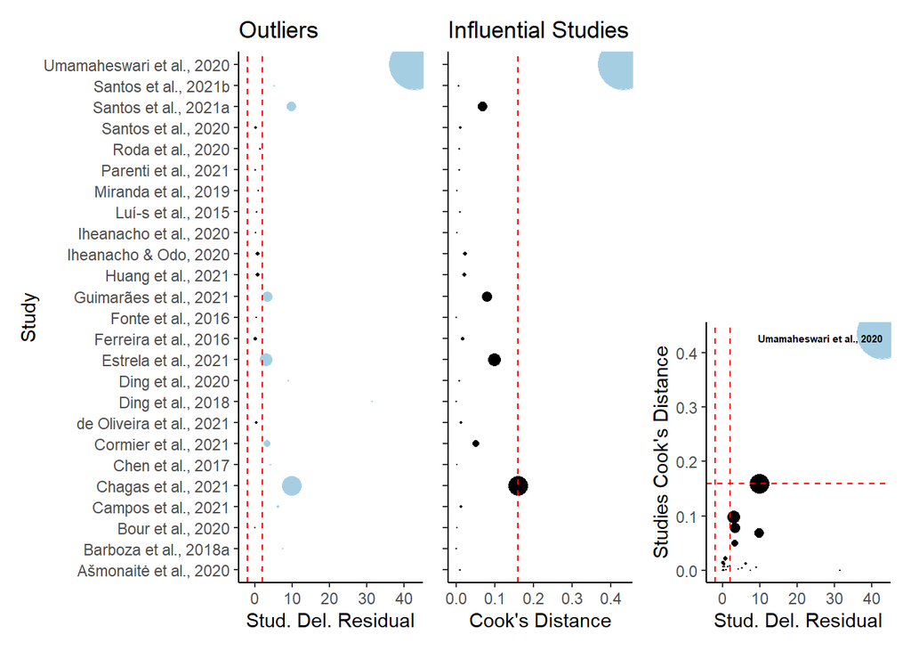

```r
influentialcases_plots(mRE, "ML_RobVar", "ML", 30)
```

# Multilevel meta-regression

SYRCLE PROTOCOL: Meta-regression will be used for outcomes with at least 10 experiments.

> The minimal number of studies or effect sizes required by a multilevel meta-regression remains unknown, albeit some simulation studies suggest that the estimates of model coefficients of a multilevel meta-regression are generally stable under various simulated situations.(Yang et al. 2023) … the complexity of parameterization of such a meta-regression requires a large dataset to make optimization algorithms free of convergence issues.(Yang et al. 2023)

## Model 1: Size, Duration, Development

```r
df_MR <- select(df, c("Year", "StudyID", "Study", "EScluster", "ESid", "DevelopmentalStage",
    "ExposureDurationDays", "ParticleSizeMean", "yi", "vi"))

mname1 <- "Reduced"
mname2 <- paste0(mname1, "_RobVar")

mods_formula <- formula(~ParticleSizeMean + ExposureDurationDays * DevelopmentalStage)

mMR[[mname1]] <- rma.mv(yi, VCV, random = RE_formula[[outcome]], mods = mods_formula,
    data = df_MR, slab = Study, method = "REML", test = "t", dfs = "contain", level = 95)  #it will only keep complete cases

nSt_MR <- mMR[[mname1]]$s.nlevels[1]  # number of studies
nEC_MR <- mMR[[mname1]]$s.nlevels[2]  # number of ESclusters
nES_MR <- mMR[[mname1]]$s.nlevels[3]  # number of independent ES

print(paste0("Number of studies: ", nSt_MR, ", number of ES clusters: ", nEC_MR,
    " and number of independent observations of ES: ", nES_MR))
```

```
[1] "Number of studies: 25, number of ES clusters: 50 and number of independent observations of ES: 83"
```

```r
mMR[[mname2]] <- robust(mMR[[mname1]], cluster = df_MR$Study, clubSandwich = TRUE,
    verbose = TRUE)
mMR[[mname2]] <- additional_results(mMR[[mname2]])

summary(mMR[[mname2]])
```

```
Multivariate Meta-Analysis Model (k = 83; method: REML)

   logLik   Deviance        AIC        BIC       AICc
-158.9800   317.9601   341.9601   369.6089   347.0748

Variance Components:

            estim    sqrt  nlvls  fixed                factor
sigma^2.1  4.0382  2.0095     25     no                 Study
sigma^2.2  0.2793  0.5285     50     no       Study/EScluster
sigma^2.3  0.1556  0.3944     83     no  Study/EScluster/ESid

Test for Residual Heterogeneity:
QE(df = 74) = 279.1360, p-val < .0001

Number of estimates:   83
Number of clusters:    25
Estimates per cluster: 0-18 (mean: 1.41, median: 0)

Test of Moderators (coefficients 2:9):¹
F(df1 = 8, df2 = 0) = 0.0000, p-val = NA

Model Results:

                                                 estimate      se¹     tval¹
intrcpt                                            0.0350  0.6205    0.0563
ParticleSizeMean                                  -0.0014  0.0030   -0.4864
ExposureDurationDays                               0.0360  0.0572    0.6293
DevelopmentalStageLarva                           -1.0694  1.1072   -0.9658
DevelopmentalStageJuvenile                        -0.5562  0.8838   -0.6293
DevelopmentalStageAdult                           -0.5714  1.3438   -0.4252
ExposureDurationDays:DevelopmentalStageLarva      -0.1239  0.2568   -0.4826
ExposureDurationDays:DevelopmentalStageJuvenile   -0.0356  0.0619   -0.5758
ExposureDurationDays:DevelopmentalStageAdult      -0.0371  0.0649   -0.5725
                                                   df¹    pval¹    ci.lb¹
intrcpt                                          1.05   0.9638   -6.9950
ParticleSizeMean                                 1.48   0.6888   -0.0195
ExposureDurationDays                             1.31   0.6209   -0.3867
DevelopmentalStageLarva                          2.35   0.4226   -5.2090
DevelopmentalStageJuvenile                       1.86   0.5976   -4.6444
DevelopmentalStageAdult                          2.02   0.7117   -6.3024
ExposureDurationDays:DevelopmentalStageLarva     1.54   0.6890   -1.6103
ExposureDurationDays:DevelopmentalStageJuvenile  2.91   0.6063   -0.2363
ExposureDurationDays:DevelopmentalStageAdult     1.77   0.6313   -0.3544
                                                  ci.ub¹
intrcpt                                          7.0649
ParticleSizeMean                                 0.0166
ExposureDurationDays                             0.4587
DevelopmentalStageLarva                          3.0702
DevelopmentalStageJuvenile                       3.5320
DevelopmentalStageAdult                          5.1596
ExposureDurationDays:DevelopmentalStageLarva     1.3625
ExposureDurationDays:DevelopmentalStageJuvenile  0.1650
ExposureDurationDays:DevelopmentalStageAdult     0.2801

---
Signif. codes:  0 '***' 0.001 '**' 0.01 '*' 0.05 '.' 0.1 ' ' 1

1) results based on cluster-robust inference (var-cov estimator: CR2,
   approx t/F-tests and confidence intervals, df: Satterthwaite approx)
```

The meta-regression comprised 83 comparisons from 50 control group clusters of 25 independent studies.

#### Diagnostics plots

|  | ML | REML |
| --- | --- | --- |
| ll | -178.1143 | -158.9800 |
| dev | 203.9921 | 317.9601 |
| AIC | 380.2287 | 341.9601 |
| BIC | 409.2548 | 369.6089 |
| AICc | 384.6858 | 347.0748 |

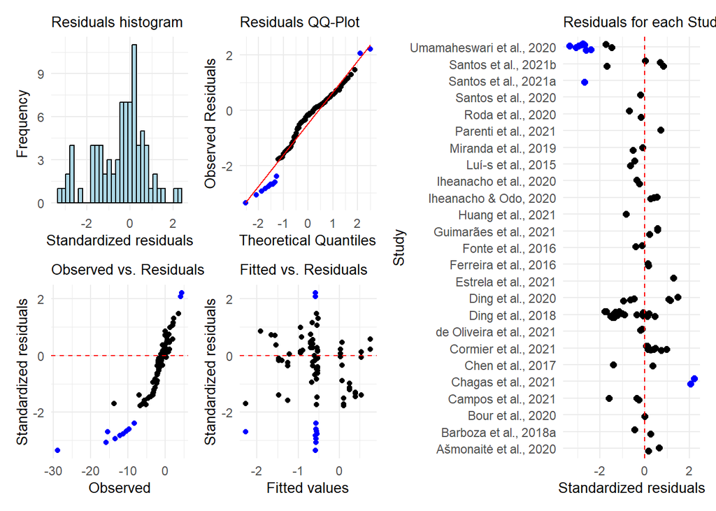

#### Influential cases

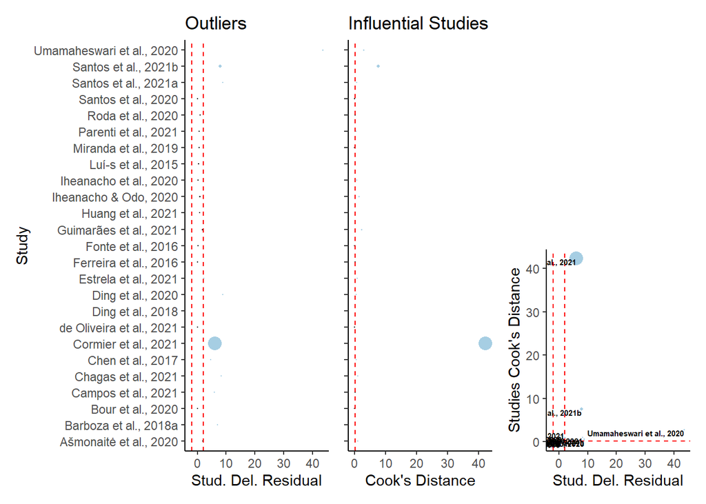

#### Orchard plots

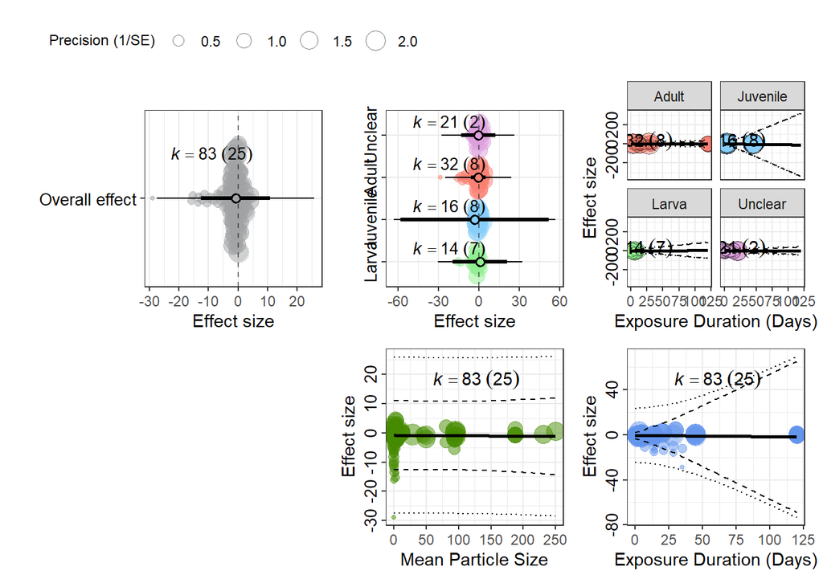

## Model 2: + Concentration

```
[1] "Number of studies: 20, number of ES clusters: 38 and number of independent observations of ES: 67"
```

```
Multivariate Meta-Analysis Model (k = 67; method: REML)

   logLik   Deviance        AIC        BIC       AICc
-133.5831   267.1662   293.1662   319.7259   301.6313

Variance Components:

            estim    sqrt  nlvls  fixed                factor
sigma^2.1  8.2402  2.8706     20     no                 Study
sigma^2.2  0.6096  0.7808     38     no       Study/EScluster
sigma^2.3  0.2958  0.5439     67     no  Study/EScluster/ESid

Test for Residual Heterogeneity:
QE(df = 57) = 246.3258, p-val < .0001

Number of estimates:   67
Number of clusters:    20
Estimates per cluster: 0-18 (mean: 1.14, median: 0)

Test of Moderators (coefficients 2:10):¹
F(df1 = 9, df2 = 0) = 0.0000, p-val = NA

Model Results:

                                                 estimate      se¹     tval¹
intrcpt                                            0.2299  0.7030    0.3271
ParticleSizeMean                                  -0.0026  0.0105   -0.2423
Concentration_mg_L                                -0.0292  0.0306   -0.9515
ExposureDurationDays                               0.0276  0.0770    0.3577
DevelopmentalStageLarva                           -1.1950  1.3476   -0.8868
DevelopmentalStageJuvenile                         0.6411  2.1657    0.2960
DevelopmentalStageAdult                            1.4048  1.4149    0.9928
ExposureDurationDays:DevelopmentalStageLarva      -0.1719  0.2994   -0.5740
ExposureDurationDays:DevelopmentalStageJuvenile   -0.4253  0.4783   -0.8893
ExposureDurationDays:DevelopmentalStageAdult      -0.2101  0.1895   -1.1087
                                                   df¹    pval¹    ci.lb¹
intrcpt                                          1.06   0.7965   -7.6608
ParticleSizeMean                                 1.29   0.8413   -0.0822
Concentration_mg_L                               1.06   0.5088   -0.3720
ExposureDurationDays                             1.24   0.7718   -0.5979
```

[output cut: 8 more lines]

```
ParticleSizeMean                                 0.0771
Concentration_mg_L                               0.3136
ExposureDurationDays                             0.6530
DevelopmentalStageLarva                          3.9544
DevelopmentalStageJuvenile                       8.8439
DevelopmentalStageAdult                          6.3900
ExposureDurationDays:DevelopmentalStageLarva     1.6612
ExposureDurationDays:DevelopmentalStageJuvenile  4.7686
ExposureDurationDays:DevelopmentalStageAdult     0.3999

---
Signif. codes:  0 '***' 0.001 '**' 0.01 '*' 0.05 '.' 0.1 ' ' 1

1) results based on cluster-robust inference (var-cov estimator: CR2,
   approx t/F-tests and confidence intervals, df: Satterthwaite approx)
```

The meta-regression comprised 67 comparisons from 38 control group clusters of 20 independent studies.

#### Diagnostics plots

|  | ML | REML |
| --- | --- | --- |
| ll | -154.1755 | -133.5831 |
| dev | 171.3831 | 267.1662 |
| AIC | 334.3511 | 293.1662 |
| BIC | 363.0121 | 319.7259 |
| AICc | 341.2190 | 301.6313 |

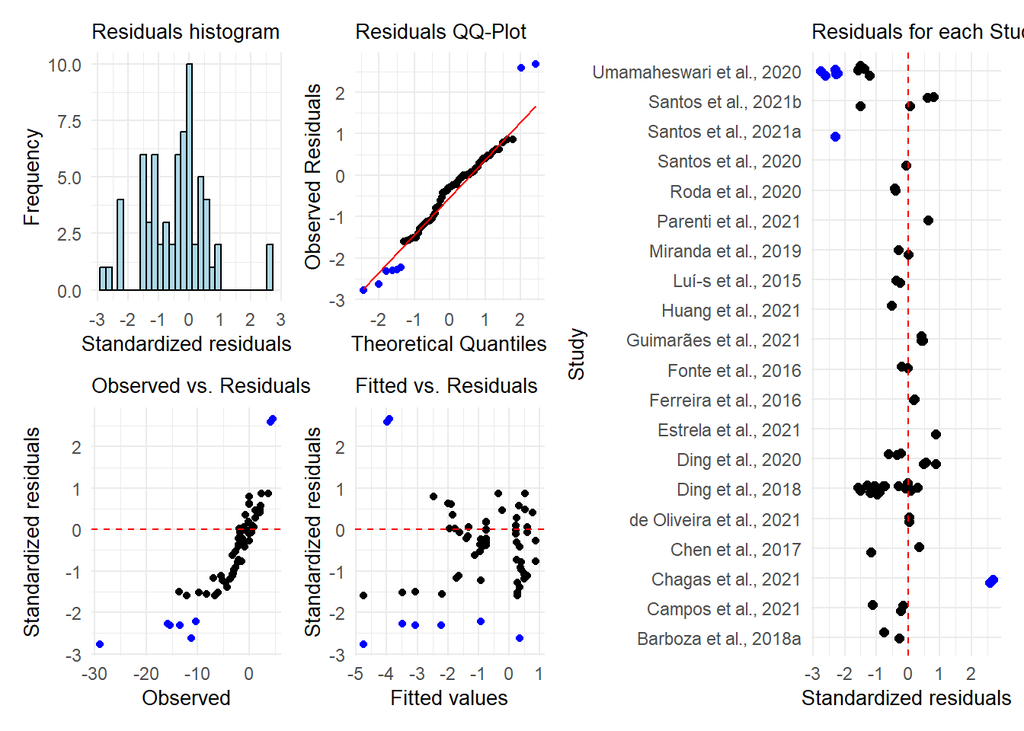

#### Influential cases

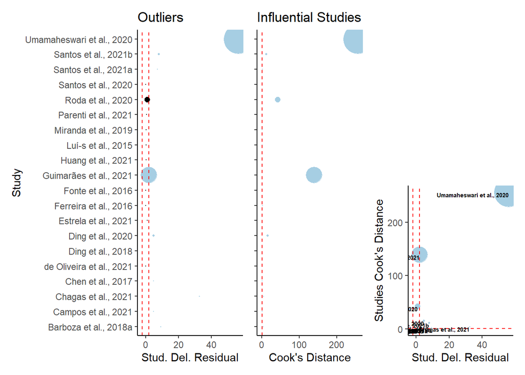

#### Orchard plots

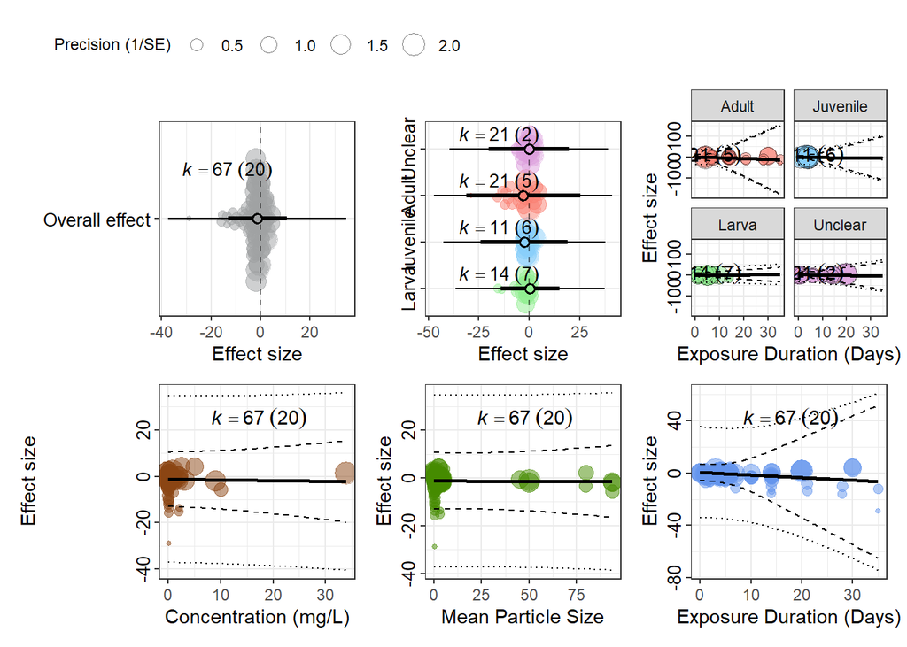

## Model 3: + ParticleMaterial

```
[1] "Number of studies: 20, number of ES clusters: 38 and number of independent observations of ES: 67"
```

```
Multivariate Meta-Analysis Model (k = 67; method: REML)

   logLik   Deviance        AIC        BIC       AICc
-121.6009   243.2017   277.2017   310.6967   294.6874

Variance Components:

            estim    sqrt  nlvls  fixed                factor
sigma^2.1  8.8164  2.9692     20     no                 Study
sigma^2.2  0.3489  0.5907     38     no       Study/EScluster
sigma^2.3  0.3040  0.5514     67     no  Study/EScluster/ESid

Test for Residual Heterogeneity:
QE(df = 53) = 200.1451, p-val < .0001

Number of estimates:   67
Number of clusters:    20
Estimates per cluster: 0-18 (mean: 1.14, median: 0)

Test of Moderators (coefficients 2:14):¹
F(df1 = 13, df2 = 0) = 0.0000, p-val = NA

Model Results:

                                                 estimate      se¹     tval¹
intrcpt                                           -0.5186  2.3465   -0.2210
ParticleSizeMean                                  -0.0008  0.0212   -0.0372
ExposureDurationDays                               0.0224  0.0727    0.3079
DevelopmentalStageLarva                           -2.2258  2.6304   -0.8462
DevelopmentalStageJuvenile                         3.0061  0.7362    4.0834
DevelopmentalStageAdult                            1.5002  1.8280    0.8207
Concentration_mg_L                                -0.0313  0.0401   -0.7812
ParticleMaterialLDPE                               1.0081  6.5144    0.1548
ParticleMaterialPE                                -2.3037  2.3610   -0.9758
ParticleMaterialPLA                                6.3720  6.2859    1.0137
ParticleMaterialPS                                 0.8919  2.2485    0.3967
ExposureDurationDays:DevelopmentalStageLarva      -0.1161  0.2892   -0.4015
ExposureDurationDays:DevelopmentalStageJuvenile   -0.3745  0.0822   -4.5569
ExposureDurationDays:DevelopmentalStageAdult      -0.2833  0.1304   -2.1721
                                                   df¹    pval¹     ci.lb¹
```

[output cut: 20 more lines]

```
DevelopmentalStageAdult                           7.5576
Concentration_mg_L                                0.4371
ParticleMaterialLDPE                             24.6203
ParticleMaterialPE                                3.3653
ParticleMaterialPLA                              29.9685
ParticleMaterialPS                                6.8004
ExposureDurationDays:DevelopmentalStageLarva      2.2642
ExposureDurationDays:DevelopmentalStageJuvenile  -0.0957   *
ExposureDurationDays:DevelopmentalStageAdult      0.1944

---
Signif. codes:  0 '***' 0.001 '**' 0.01 '*' 0.05 '.' 0.1 ' ' 1

1) results based on cluster-robust inference (var-cov estimator: CR2,
   approx t/F-tests and confidence intervals, df: Satterthwaite approx)
```

The meta-regression comprised 67 comparisons from 38 control group clusters of 20 independent studies.

#### Diagnostics plots

|  | ML | REML |
| --- | --- | --- |
| ll | -151.0246 | -121.6009 |
| dev | 165.0811 | 243.2017 |
| AIC | 336.0491 | 277.2017 |
| BIC | 373.5289 | 310.6967 |
| AICc | 348.5389 | 294.6874 |

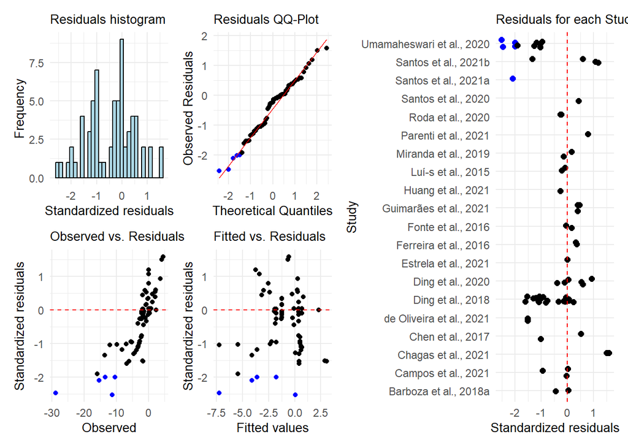

#### Orchard plots

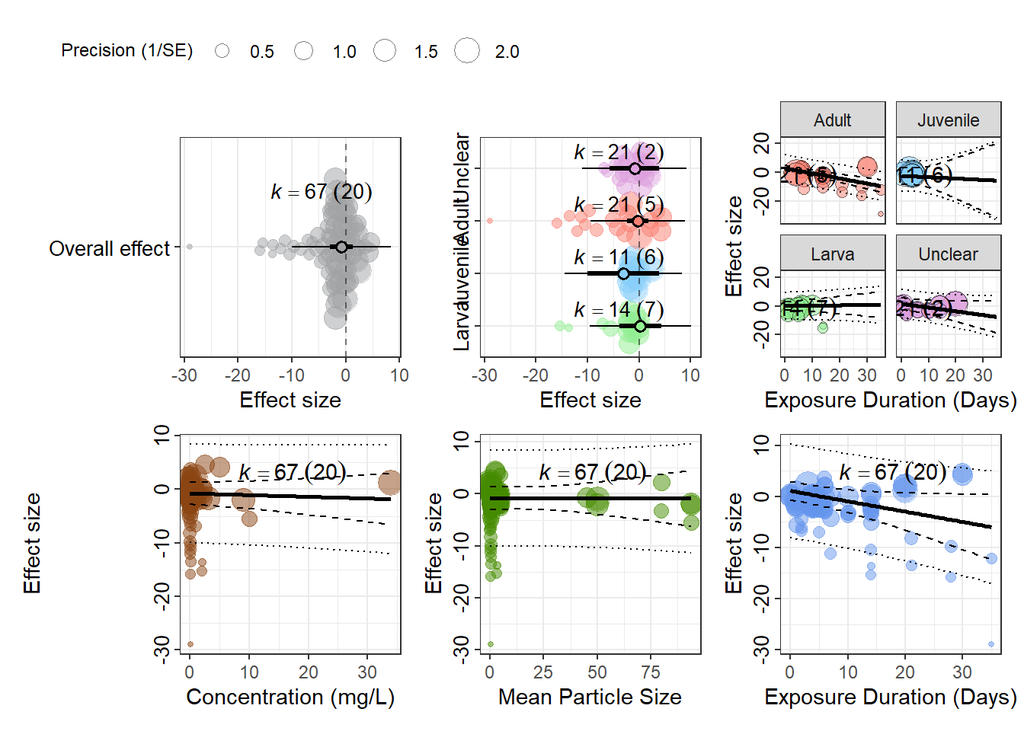

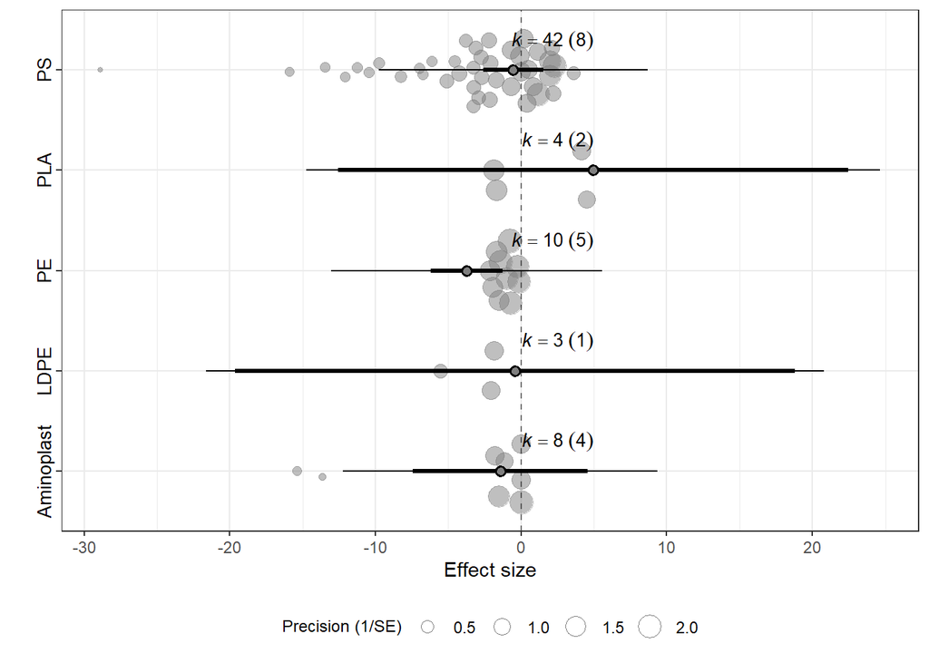

# Referências

Harrer, Mathias, Pim Cuijpers, Toshi A. Furukawa, and David D. Ebert. n.d. *Chapter 9 Publication Bias | Doing Meta-Analysis in R*. https://bookdown.org/MathiasHarrer/Doing_Meta_Analysis_in_R/pub-bias.html.

Nakagawa, Shinichi, Malgorzata Lagisz, Michael D. Jennions, Julia Koricheva, Daniel W. A. Noble, Timothy H. Parker, Alfredo Sánchez-Tójar, Yefeng Yang, and Rose E. O’Dea. 2022. “Methods for Testing Publication Bias in Ecological and Evolutionary Meta-Analyses.” *Methods in Ecology and Evolution* 13 (1): 4–21. https://doi.org/10.1111/2041-210X.13724.

Viechtbauer, Wolfgang, and Mike W.-L. Cheung. 2010. “Outlier and Influence Diagnostics for Meta-Analysis.” *Research Synthesis Methods* 1 (2): 112–25. https://doi.org/10.1002/jrsm.11.

Yang, Yefeng, Malcolm Macleod, Jinming Pan, Malgorzata Lagisz, and Shinichi Nakagawa. 2023. “Advanced Methods and Implementations for the Meta-Analyses of Animal Models: Current Practices and Future Recommendations.” *Neuroscience & Biobehavioral Reviews* 146 (March): 105016. https://doi.org/10.1016/j.neubiorev.2022.105016.